# IODS course project

tihig - CS-student with keen interest on Computational Data Science

# About the project

*In this course we will get know the tools and methods for open data science. The tools in this course include R, Rmarkdown and Github and we will also learn programming with R from Datacamp exercises. This is a really cool course, so what are you waiting for? Join in! The full link to this course diary can be found below:*

[Github-repo](https://github.com/tihig/IODS-project)

# Chapter 2: Regression and Model Validation

## Introduction

In here, I first read the content of the table to variable lrn14 from given URL. The table has information of “Johdatus tilastotieteeseen”- courses survey. Let’s look at the overall structure of the table.

```
## 'data.frame':    166 obs. of  7 variables:
##  $ gender  : Factor w/ 2 levels "F","M": 1 2 1 2 2 1 2 1 2 1 ...
##  $ Age     : int  53 55 49 53 49 38 50 37 37 42 ...
##  $ Attitude: int  37 31 25 35 37 38 35 29 38 21 ...
##  $ deep    : num  3.75 2.88 3.88 3.5 3.75 ...
##  $ stra    : num  3.38 2.75 3.62 3.12 3.62 ...
##  $ surf    : num  2.58 3.17 2.25 2.25 2.83 ...
##  $ Points  : int  25 12 24 10 22 21 21 31 24 26 ...
```

```
## [1] 166   7
```

As we can see here, there are seven columns in this table: Gender, Age, Attitude, Deep, Stra, Surf and Points. The values of columns are separated by comma “,”.Gender and Age are pretty self- explanatory: age and gender of participant of the survey. Attitude questions asked about participants attitude towards statistics. Deep, Stra and Surf describe the questions given in the survey as being deep, strategic or surface. The last column Points is the points this participant got from the course exam.

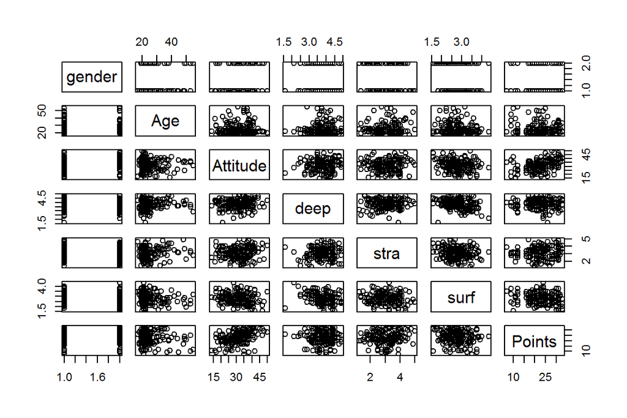

Here is the graphical overview of the table. It is visible in this overview that strategic and surf questions are somehow correlated. The surveys participants are mostly close to age 20 and exam points are fairly evenly distributed.

```r
summary(lrn14$gender)
```

```
##   F   M
## 110  56
```

```r
summary(lrn14$Age)
```

```
##    Min. 1st Qu.  Median    Mean 3rd Qu.    Max.
##   17.00   21.00   22.00   25.51   27.00   55.00
```

```r
summary(lrn14$Attitude)
```

```
##    Min. 1st Qu.  Median    Mean 3rd Qu.    Max.
##   14.00   26.00   32.00   31.43   37.00   50.00
```

```r
summary(lrn14$deep)
```

```
##    Min. 1st Qu.  Median    Mean 3rd Qu.    Max.
##   1.625   3.500   3.875   3.796   4.250   4.875
```

```r
summary(lrn14$stra)
```

```
##    Min. 1st Qu.  Median    Mean 3rd Qu.    Max.
##   1.250   2.625   3.188   3.121   3.625   5.000
```

```r
summary(lrn14$surf)
```

```
##    Min. 1st Qu.  Median    Mean 3rd Qu.    Max.
##   1.583   2.417   2.833   2.787   3.167   4.333
```

```r
summary(lrn14$Points)
```

```
##    Min. 1st Qu.  Median    Mean 3rd Qu.    Max.
##    7.00   19.00   23.00   22.72   27.75   33.00
```

The exact information is easier viewed from the summaries of the columns. In the overview it was hard to determine what was the ratio of genders, but in here we can see that there were more female participants than male.

And what comes to the results, some questions did get maximum points from the scale (e.g Strategic and Attitude). Most of the mean values are above the mean of the in total.

## Regression model

```
##
## Call:
## lm(formula = Points ~ Attitude, data = lrn14)
##
## Residuals:
##      Min       1Q   Median       3Q      Max
## -16.9763  -3.2119   0.4339   4.1534  10.6645
##
## Coefficients:
##             Estimate Std. Error t value Pr(>|t|)
## (Intercept) 11.63715    1.83035   6.358 1.95e-09 ***
## Attitude     0.35255    0.05674   6.214 4.12e-09 ***
## ---
## Signif. codes:  0 '***' 0.001 '**' 0.01 '*' 0.05 '.' 0.1 ' ' 1
##
## Residual standard error: 5.32 on 164 degrees of freedom
## Multiple R-squared:  0.1906, Adjusted R-squared:  0.1856
## F-statistic: 38.61 on 1 and 164 DF,  p-value: 4.119e-09
```

Above here is the multiple regression models summary. First, let’s look at the residuals. The values of residuals look normal distributed, which means that the values read from left to right would make a Gaus curve if drawn.

The stars on the right side of values represent the significance of the variables. The more stars, the more significant it is. Attitude has clearly a significance whereas surface, strategic and deep had no stars at all. These are not visible, since the description of exercise told to remove them.

The multiple R squared of the model is approx. 0,19. The best value is 1, therefore this model is moderate and means that ~19% of the cause of exam points is due to attitude. Warning: remember that correlation is not always same as causality!

## Diagnostic plots

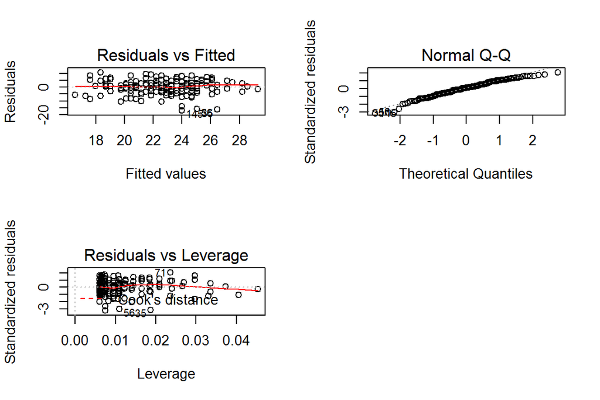

The last charts are the diagnostics plots for the model. According to the values seen before, assumption is that the modle is moderate: some values fit the prediction and some do not.The suprising element here is that only chart that fits is Normal QQ.On the other hand, Residuals vs. Fitted and Residuals vs. Leverage resemble the multiple R squared value of ~19%. This conludes that fact that this model is neither good or bad.

# Chapter 3: Logistic Regression

## Introduction and hypothesis

In this analysis a data chart of student alcohol consumption in Portugal is used in examination of it’s previously counted variable high use. In this chapter I’ll choose 4 interesting variables and present a hypothesis on how they correlate with high/low alchohol consupmtion. The variables I choose are failure, study time, health and absences from school. Here are the hypothesis I will study through this chapter:

H1: High alcohol consumption affects amount of course failures. H2: More time spent on studying implys less alcohol consupmtion H3: Higher health indicates less alcohol consumption. H4: High amount of absences are related to high alcohol consumption.

Let’s look at the variables individually. These variables are now extraced to their own table, so we can look them with glimpse- function.

```
## Observations: 382
## Variables: 5
## $ high_use  <lgl> FALSE, FALSE, TRUE, FALSE, FALSE, FALSE, FALSE, FALS...
## $ failures  <int> 0, 0, 2, 0, 0, 0, 0, 0, 0, 0, 0, 0, 0, 0, 0, 0, 0, 0...
## $ studytime <int> 2, 2, 2, 3, 2, 2, 2, 2, 2, 2, 2, 3, 1, 2, 3, 1, 3, 2...
## $ health    <int> 3, 3, 3, 5, 5, 5, 3, 1, 1, 5, 2, 4, 5, 3, 3, 2, 2, 4...
## $ absences  <int> 5, 3, 8, 1, 2, 8, 0, 4, 0, 0, 1, 2, 1, 1, 0, 5, 8, 3...
```

```
## Observations: 1,910
## Variables: 2
## $ key   <chr> "high_use", "high_use", "high_use", "high_use", "high_us...
## $ value <int> 0, 0, 1, 0, 0, 0, 0, 0, 0, 0, 0, 0, 0, 0, 0, 0, 0, 0, 1,...
```

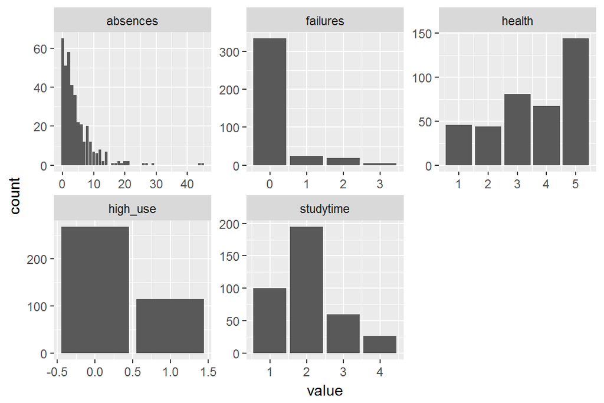

Over 300 of the student have no failures on their courses and under a hundred student have some failures according to the first chart. absences Even more divided is the section for health. Clearly the biggest number of answers got 5 = very good, but the proprotion of student that answered either 1= Very bad or 2 = bad is combined almost half of the amount of students that answered 5. In alcohol consumption, our key variable here, over 100 students are high users (calculated as the mean of weekend and daily use).

There can be no further conclusions divided from this set of data, so let’s dig deeper.

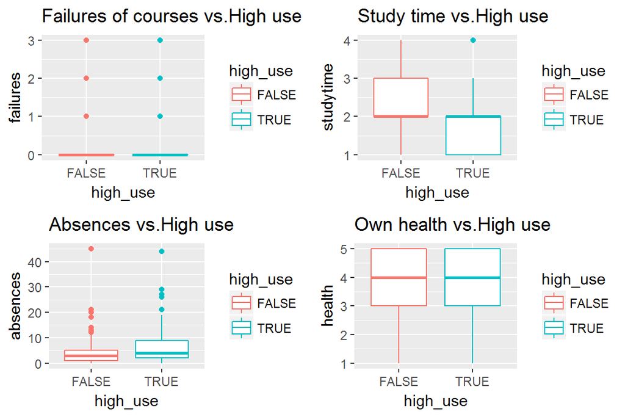

Here we can see that one from our models is not good (atleast as boxplot). Failures show only two lines and is therefore hard to make conclusion on one way or another.

On the other hand, health, study time and absence are vieweable and show some concluding evidence. People who are not high users answered that they spend more time studying than high users. Also, people who are high users have more absences compared to non-high users. What is suprising here is that both high users and non- high users have the same values of answers in health, meaning regardless of alcohol usage level they feel enough healthy.

Let’s still keep the values here to see if the chosen plot type had effect on the results. Next, I will make a model using logistic regression. This type of analysis style is good, if variables have a fair amount of two- digit variables (only values true/false or yes/no eg.).

## Logistic Regression

```
##
## Call:
## glm(formula = high_use ~ failures + health + absences + studytime,
##     family = "binomial", data = alc_hyp)
##
## Deviance Residuals:
##     Min       1Q   Median       3Q      Max
## -2.1963  -0.8269  -0.6563   1.1481   2.1371
##
## Coefficients:
##             Estimate Std. Error z value Pr(>|z|)
## (Intercept) -0.61068    0.48357  -1.263 0.206644
## failures     0.34984    0.19053   1.836 0.066340 .
## health       0.06454    0.08564   0.754 0.451093
## absences     0.07921    0.02269   3.491 0.000482 ***
## studytime   -0.47935    0.15876  -3.019 0.002534 **
## ---
## Signif. codes:  0 '***' 0.001 '**' 0.01 '*' 0.05 '.' 0.1 ' ' 1
##
## (Dispersion parameter for binomial family taken to be 1)
##
##     Null deviance: 465.68  on 381  degrees of freedom
## Residual deviance: 429.40  on 377  degrees of freedom
## AIC: 439.4
##
## Number of Fisher Scoring iterations: 4
```

Let’s drop the unsignificant variable health and see what the variables look afterwards.

```
##
## Call:
## glm(formula = high_use ~ absences + failures + studytime, family = "binomial",
##     data = alc_hyp)
##
## Deviance Residuals:
##     Min       1Q   Median       3Q      Max
## -2.1536  -0.8385  -0.6825   1.1469   2.1604
##
## Coefficients:
##             Estimate Std. Error z value Pr(>|z|)
## (Intercept) -0.36590    0.35603  -1.028 0.304080
## absences     0.07897    0.02271   3.477 0.000507 ***
## failures     0.36378    0.19023   1.912 0.055845 .
## studytime   -0.48619    0.15855  -3.066 0.002166 **
## ---
## Signif. codes:  0 '***' 0.001 '**' 0.01 '*' 0.05 '.' 0.1 ' ' 1
##
## (Dispersion parameter for binomial family taken to be 1)
##
##     Null deviance: 465.68  on 381  degrees of freedom
## Residual deviance: 429.97  on 378  degrees of freedom
## AIC: 437.97
##
## Number of Fisher Scoring iterations: 4
```

Now the models coefficents are more significant and we can continue exploring this model as a valid model.

```
##                    OR     2.5 %    97.5 %
## (Intercept) 0.6935745 0.3442726 1.3944631
## absences    1.0821747 1.0373417 1.1341316
## failures    1.4387512 0.9917543 2.1021998
## studytime   0.6149678 0.4465274 0.8325472
```

## Prediction

```
##         prediction
## high_use FALSE TRUE
##    FALSE   254   14
##    TRUE     91   23
```

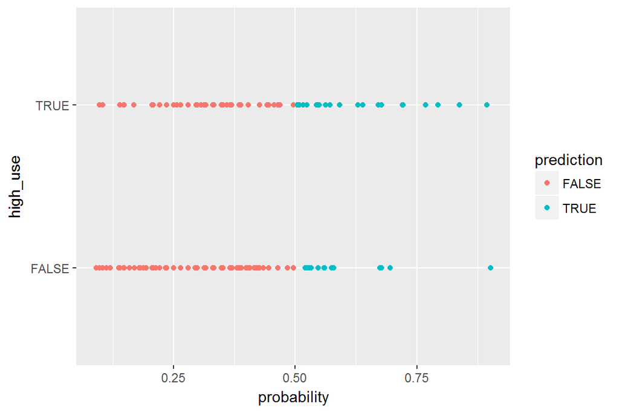

In the upper table and chart we can see the comparison of prediction of high use and current datas high use. The chart is pretty scattered and shows that this model is not the best one to be viewed with only two variables.

```
## [1] 0.2748691
```

In the above is the size of average false prediction in this model. This means that approximately 27% of the predictions this model makes are false. The performance of this model is not as good as expected in the beginning (hypothesis) and compared to simple guessing tactique this model is slightly more accurate.

## 10-fold validation

```
## [1] 0.2853403
```

Last here is the 10-fold cross validation performed for this table. Unfortunately this model does not have smaller prediction error as in the DataCamp exercises ( approx. 0.26), but still is fairly close to it.

# Chapter 4: Clustering and classification

## Introduction

In this chapter I will look into closely to Boston dataframe that has 506 rows and 14 columns. The dataframe contains information about factors effecting housing values in suburban areas of Boston. These factors (further addessed as variables) include e.g crimerate (crim), full value property tax rate per 10000$ (tax) and pupil- teacher ratio (pratio). Full description of the data frame can be found here: [Housing Values in Suburbs of Boston](https://stat.ethz.ch/R-manual/R-devel/library/MASS/html/Boston.html)

```
##  [1] "crim"    "zn"      "indus"   "chas"    "nox"     "rm"      "age"
##  [8] "dis"     "rad"     "tax"     "ptratio" "black"   "lstat"   "medv"
```

```
## 'data.frame':    506 obs. of  14 variables:
##  $ crim   : num  0.00632 0.02731 0.02729 0.03237 0.06905 ...
##  $ zn     : num  18 0 0 0 0 0 12.5 12.5 12.5 12.5 ...
##  $ indus  : num  2.31 7.07 7.07 2.18 2.18 2.18 7.87 7.87 7.87 7.87 ...
##  $ chas   : int  0 0 0 0 0 0 0 0 0 0 ...
##  $ nox    : num  0.538 0.469 0.469 0.458 0.458 0.458 0.524 0.524 0.524 0.524 ...
##  $ rm     : num  6.58 6.42 7.18 7 7.15 ...
##  $ age    : num  65.2 78.9 61.1 45.8 54.2 58.7 66.6 96.1 100 85.9 ...
##  $ dis    : num  4.09 4.97 4.97 6.06 6.06 ...
##  $ rad    : int  1 2 2 3 3 3 5 5 5 5 ...
##  $ tax    : num  296 242 242 222 222 222 311 311 311 311 ...
##  $ ptratio: num  15.3 17.8 17.8 18.7 18.7 18.7 15.2 15.2 15.2 15.2 ...
##  $ black  : num  397 397 393 395 397 ...
##  $ lstat  : num  4.98 9.14 4.03 2.94 5.33 ...
##  $ medv   : num  24 21.6 34.7 33.4 36.2 28.7 22.9 27.1 16.5 18.9 ...
```

```
## [1] 506  14
```

Below is a graphical overview done with pairs- function and the full summary of all variables.

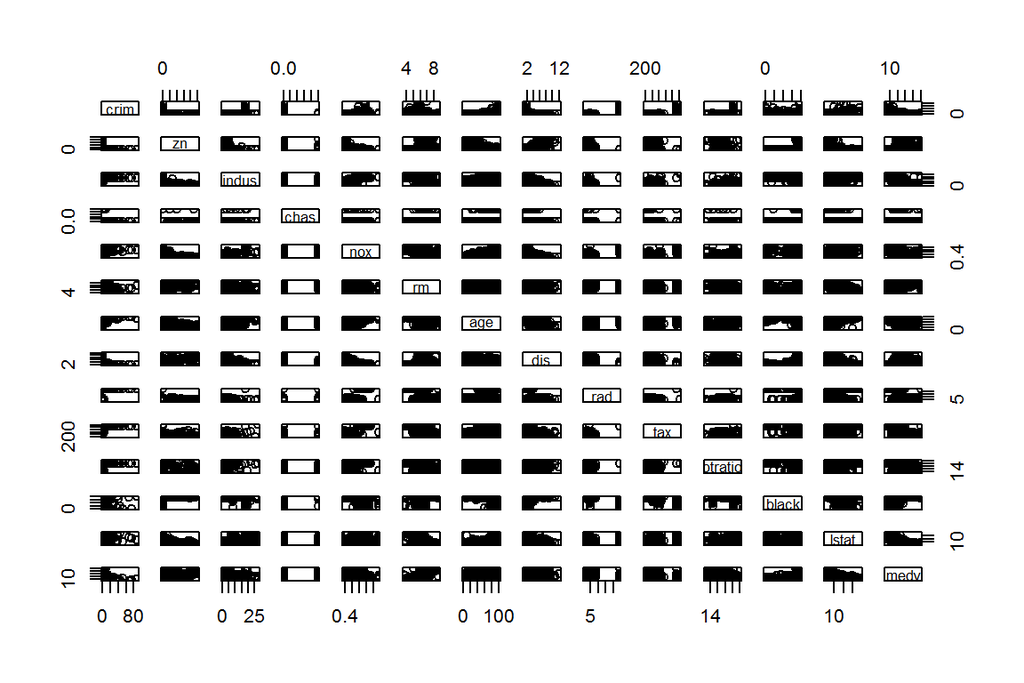

```
##       crim                zn             indus            chas
##  Min.   : 0.00632   Min.   :  0.00   Min.   : 0.46   Min.   :0.00000
##  1st Qu.: 0.08204   1st Qu.:  0.00   1st Qu.: 5.19   1st Qu.:0.00000
##  Median : 0.25651   Median :  0.00   Median : 9.69   Median :0.00000
##  Mean   : 3.61352   Mean   : 11.36   Mean   :11.14   Mean   :0.06917
##  3rd Qu.: 3.67708   3rd Qu.: 12.50   3rd Qu.:18.10   3rd Qu.:0.00000
##  Max.   :88.97620   Max.   :100.00   Max.   :27.74   Max.   :1.00000
##       nox               rm             age              dis
##  Min.   :0.3850   Min.   :3.561   Min.   :  2.90   Min.   : 1.130
##  1st Qu.:0.4490   1st Qu.:5.886   1st Qu.: 45.02   1st Qu.: 2.100
##  Median :0.5380   Median :6.208   Median : 77.50   Median : 3.207
##  Mean   :0.5547   Mean   :6.285   Mean   : 68.57   Mean   : 3.795
##  3rd Qu.:0.6240   3rd Qu.:6.623   3rd Qu.: 94.08   3rd Qu.: 5.188
##  Max.   :0.8710   Max.   :8.780   Max.   :100.00   Max.   :12.127
##       rad              tax           ptratio          black
##  Min.   : 1.000   Min.   :187.0   Min.   :12.60   Min.   :  0.32
##  1st Qu.: 4.000   1st Qu.:279.0   1st Qu.:17.40   1st Qu.:375.38
##  Median : 5.000   Median :330.0   Median :19.05   Median :391.44
##  Mean   : 9.549   Mean   :408.2   Mean   :18.46   Mean   :356.67
##  3rd Qu.:24.000   3rd Qu.:666.0   3rd Qu.:20.20   3rd Qu.:396.23
##  Max.   :24.000   Max.   :711.0   Max.   :22.00   Max.   :396.90
##      lstat            medv
##  Min.   : 1.73   Min.   : 5.00
##  1st Qu.: 6.95   1st Qu.:17.02
##  Median :11.36   Median :21.20
##  Mean   :12.65   Mean   :22.53
##  3rd Qu.:16.95   3rd Qu.:25.00
##  Max.   :37.97   Max.   :50.00
```

From the summary, we can see that all the variables in this data frame are numeric. All the data in this frame is percents, proprotions, mean or median values or calculated with their own function. For example Medv is the median value of homes in 1000$s and black is the amount of blacks calculated with the following function: 1000(Bk - 0.63)^2, Bk is the proportion of blacks per town. As an exception to others, Charles River dummy variable (Chas) is a binary variable with values 1 or 0 indicating if the river crosses the area or not.

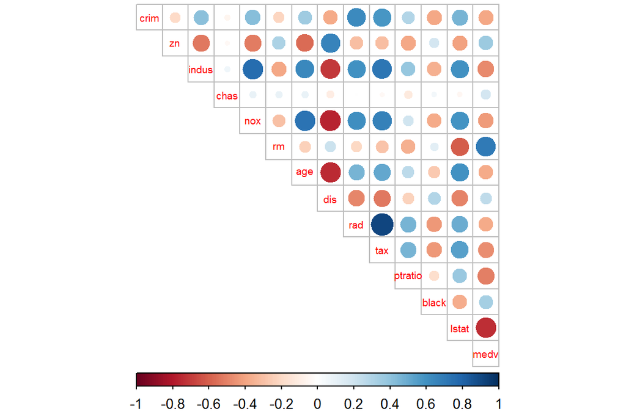

Above is the correlation chart of the values. Size of the circle varies according to correlation coefficents. The color of the circle indicates whether it is negatively or positively correlating.

## Standardizing

```
##       crim                 zn               indus
##  Min.   :-0.419367   Min.   :-0.48724   Min.   :-1.5563
##  1st Qu.:-0.410563   1st Qu.:-0.48724   1st Qu.:-0.8668
##  Median :-0.390280   Median :-0.48724   Median :-0.2109
##  Mean   : 0.000000   Mean   : 0.00000   Mean   : 0.0000
##  3rd Qu.: 0.007389   3rd Qu.: 0.04872   3rd Qu.: 1.0150
##  Max.   : 9.924110   Max.   : 3.80047   Max.   : 2.4202
##       chas              nox                rm               age
##  Min.   :-0.2723   Min.   :-1.4644   Min.   :-3.8764   Min.   :-2.3331
##  1st Qu.:-0.2723   1st Qu.:-0.9121   1st Qu.:-0.5681   1st Qu.:-0.8366
##  Median :-0.2723   Median :-0.1441   Median :-0.1084   Median : 0.3171
##  Mean   : 0.0000   Mean   : 0.0000   Mean   : 0.0000   Mean   : 0.0000
##  3rd Qu.:-0.2723   3rd Qu.: 0.5981   3rd Qu.: 0.4823   3rd Qu.: 0.9059
##  Max.   : 3.6648   Max.   : 2.7296   Max.   : 3.5515   Max.   : 1.1164
##       dis               rad               tax             ptratio
##  Min.   :-1.2658   Min.   :-0.9819   Min.   :-1.3127   Min.   :-2.7047
##  1st Qu.:-0.8049   1st Qu.:-0.6373   1st Qu.:-0.7668   1st Qu.:-0.4876
##  Median :-0.2790   Median :-0.5225   Median :-0.4642   Median : 0.2746
##  Mean   : 0.0000   Mean   : 0.0000   Mean   : 0.0000   Mean   : 0.0000
##  3rd Qu.: 0.6617   3rd Qu.: 1.6596   3rd Qu.: 1.5294   3rd Qu.: 0.8058
##  Max.   : 3.9566   Max.   : 1.6596   Max.   : 1.7964   Max.   : 1.6372
##      black             lstat              medv
##  Min.   :-3.9033   Min.   :-1.5296   Min.   :-1.9063
##  1st Qu.: 0.2049   1st Qu.:-0.7986   1st Qu.:-0.5989
##  Median : 0.3808   Median :-0.1811   Median :-0.1449
##  Mean   : 0.0000   Mean   : 0.0000   Mean   : 0.0000
##  3rd Qu.: 0.4332   3rd Qu.: 0.6024   3rd Qu.: 0.2683
##  Max.   : 0.4406   Max.   : 3.5453   Max.   : 2.9865
```

```
## [1] "matrix"
```

```
##      Min.   1st Qu.    Median      Mean   3rd Qu.      Max.
## -0.419400 -0.410600 -0.390300  0.000000  0.007389  9.924000
```

```
## crime
##      low  med_low med_high     high
##      127      126      126      127
```

```
## [1] "Training set"
```

```
## [1] 404
```

```
## [1] "Testing set"
```

```
## [1] 102
```

I divided the scaled data frame into two sets: test and training set. The training set has 80% of the data from Boston scaled and the total number of rows for both sets is printed here.

## Linear Discriminant Analysis (LDA)

In this section, I fitted a Linear Discriminant Analysis (LDA, in short) by choosing categorial variable crime as target variable and rest as explanatory in R:s lda- function.

```
## Call:
## lda(crime ~ ., data = train)
##
## Prior probabilities of groups:
##       low   med_low  med_high      high
## 0.2500000 0.2574257 0.2425743 0.2500000
##
## Group means:
##                   zn      indus       chas        nox          rm
## low       0.93959205 -0.8913242 -0.1164043 -0.8817254  0.44478580
## med_low  -0.08918369 -0.3994594  0.0305248 -0.5995535 -0.07742996
## med_high -0.39886078  0.1659724  0.1294159  0.3783797 -0.01429306
## high     -0.48724019  1.0171306 -0.1553855  1.0342760 -0.37476677
##                 age        dis        rad        tax    ptratio
## low      -0.8726115  0.8653857 -0.6816778 -0.7446109 -0.4331341
## med_low  -0.3648493  0.3764670 -0.5467789 -0.5433444 -0.1318007
## med_high  0.3410294 -0.3555981 -0.3771682 -0.2776135 -0.1967448
## high      0.7783003 -0.8513551  1.6379981  1.5139626  0.7806252
##                black       lstat        medv
## low       0.37842268 -0.74852197  0.51553740
## med_low   0.32804216 -0.18784723  0.06627101
## med_high  0.04964122  0.06580197  0.06732929
## high     -0.81282453  0.92360927 -0.73862406
##
## Coefficients of linear discriminants:
##                 LD1         LD2         LD3
## zn       0.08597347  0.79498623 -1.00648765
## indus   -0.01168035 -0.22983049  0.16704176
## chas    -0.08534018 -0.07427468  0.13262942
## nox      0.37690683 -0.71448016 -1.48801639
## rm      -0.07627336 -0.02529739 -0.13920601
## age      0.20329888 -0.16985152 -0.05589623
## dis     -0.14701907 -0.18028708  0.14421026
## rad      2.85584407  1.15546940  0.17154567
## tax      0.11049098 -0.24507915  0.48421831
## ptratio  0.12241860 -0.03650853 -0.40386924
## black   -0.13436011  0.02227232  0.12136022
## lstat    0.21643880 -0.25166822  0.33323708
## medv     0.14439470 -0.48275320 -0.21593436
##
## Proportion of trace:
##    LD1    LD2    LD3
## 0.9471 0.0402 0.0127
```

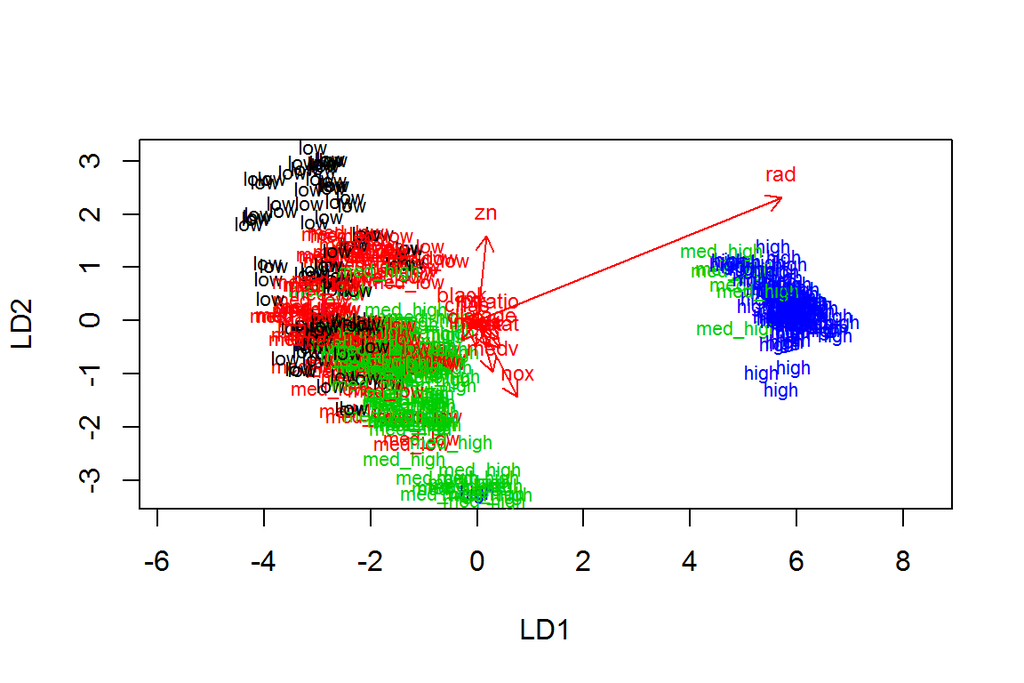

The graph of LDA model shows that clearly high crime rate stands out from the rest of the data. Also, index of accessibility to radial highways (rad) is separated from the rest of the arrows and pointing towards high value of crime rate.

```
##           predicted
## correct    low med_low med_high high
##   low       14       9        3    0
##   med_low    4       9        9    0
##   med_high   0       9       19    0
##   high       0       0        0   26
```

## K-means

Unlike LDA, K-means is a clustering method that divides observations into clusters. The number of clusters is determined beforehand by adding number of centers as attribute to K-means function.

First, I reloaded the Boston data frame and scaled it again. Inorder execute K-means, the distances of observation need to be calculated. I used here eucledian, since it’s the most popular distance measurement type.

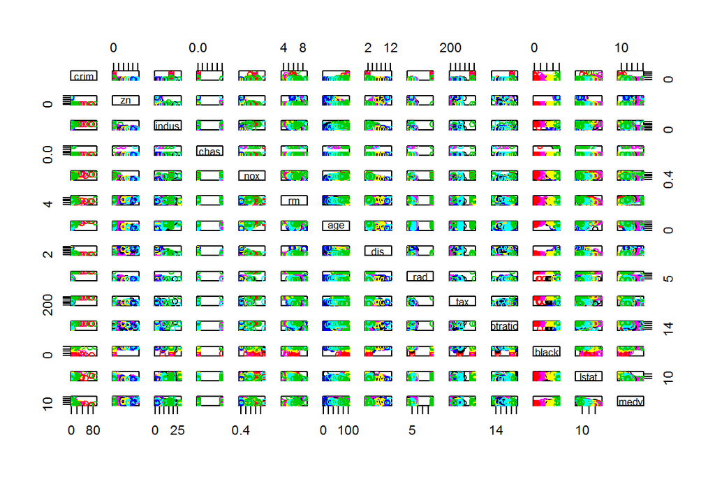

Above is the plot of Boston data frame coloured with K-means clusters. K-means is ran here with 15 clusters. The graph is difficult to interpret, which could be because of wrong number of clusters. Let’s determine the correct amount of clusters using the total of within cluster sum of squares (WCSS).

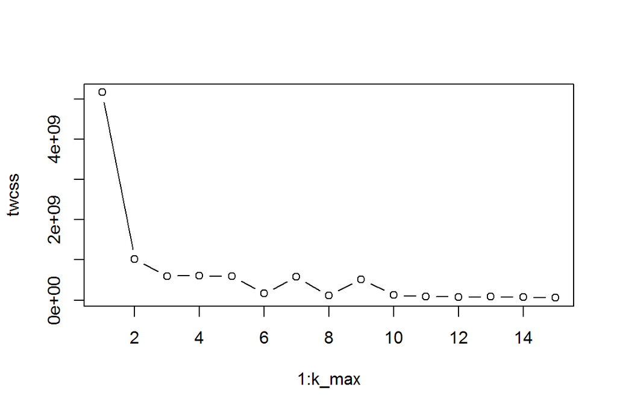

From the visualization of the result, we can see that the biggest drop of total WCSS is when the amount of clusters is 2. This means that 2 clusters is the best amount for our data frame.

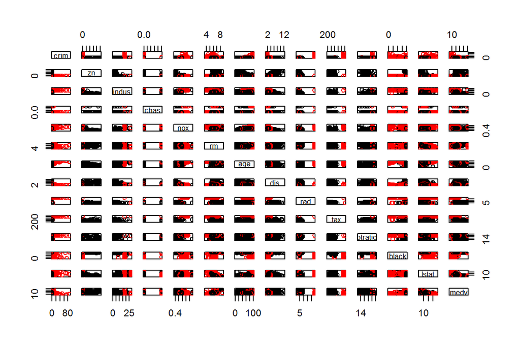

## Bonus

To execute the bonus task I reloaded the Boston dataset and standardized it again. The graph below shows the K-means clustering of this dataset with 4 centers.

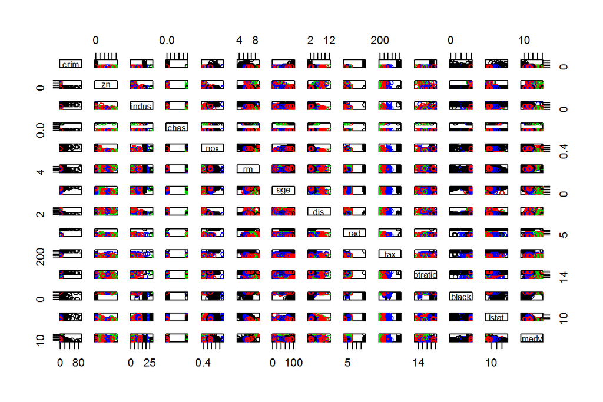

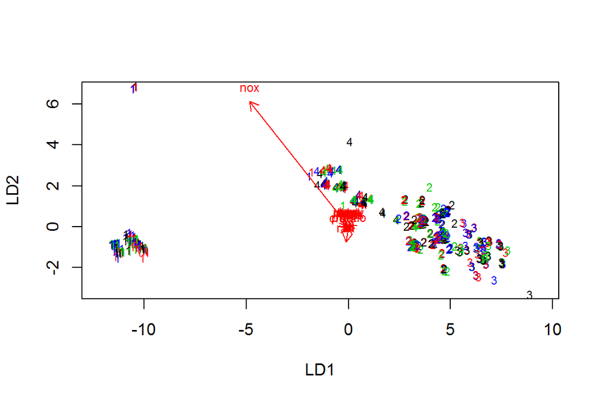

The graph above is LDA model with the K-means clusters as target variable and Boston data frame as data. The variable with the longest arrow is nitrogen oxides concentration (nox) and it divides the data frames observations into two separate areas. From the other variables it is harder to say which one could be influential linear separator, so let’s look at the graphs vectors more closely.

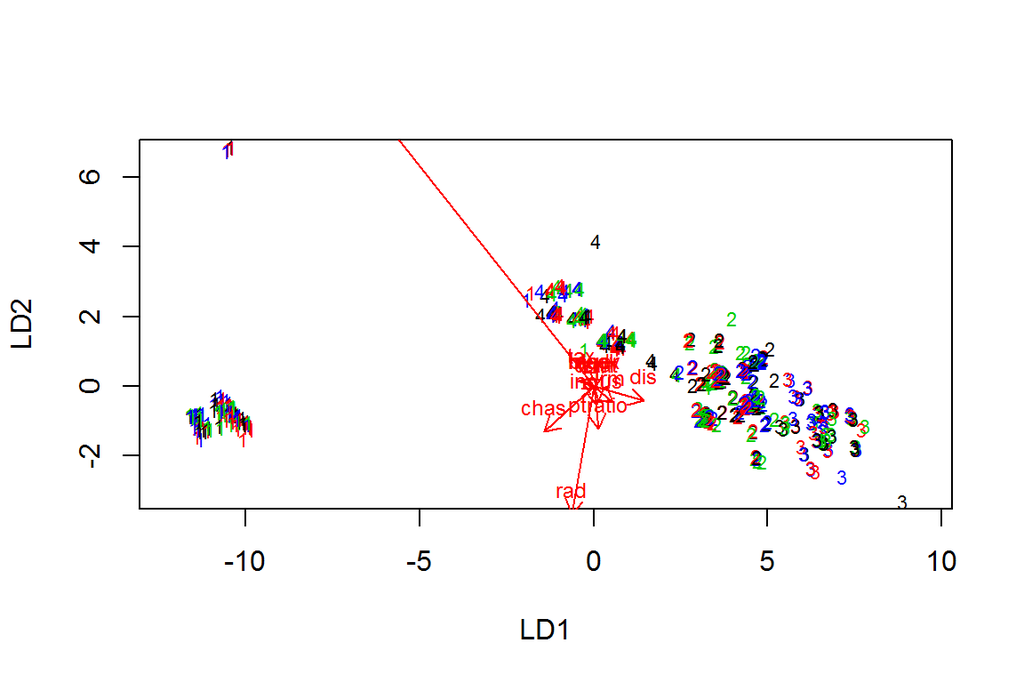

The two variables showing to be linear separators are variables index of accessibility to radial highways (rad) and Charles River dummy variable (chas) that separate the observations from cluster one from the rest of the group.

## Super bonus

```
## [1] 404  13
```

```
## [1] 13  3
```

[interactive chart not shown]

As a super bonus task I ran the given code that makes the three matrix products from previous LDA (not the one in Bonus task) and inserts the into plot_ly function. The result is this beautiful 3D graph. If you move your mouse over the observations, you can see their exact coordinates.

# Chapter 5: Dimensionality reduction techniques

## Introduction

In this chapter I will wrangle and analyse data from UNs Development programs Human Development Index (HDI) and Gender Inequality Index data frames. These are combined together to be a data frame named “Human”. More about the data frame here: [UN development programs: HDI](http://hdr.undp.org/en/content/human-development-index-hdi)

```
## 'data.frame':    155 obs. of  9 variables:
##  $ X        : Factor w/ 155 levels "Afghanistan",..: 105 6 134 41 101 54 67 149 28 102 ...
##  $ Edu2.FM  : num  1.007 0.997 0.983 0.989 0.969 ...
##  $ Labo.FM  : num  0.891 0.819 0.825 0.884 0.829 ...
##  $ Life.Exp : num  81.6 82.4 83 80.2 81.6 80.9 80.9 79.1 82 81.8 ...
##  $ Edu.Exp  : num  17.5 20.2 15.8 18.7 17.9 16.5 18.6 16.5 15.9 19.2 ...
##  $ GNI      : Factor w/ 155 levels "1,123","1,228",..: 132 109 124 112 113 111 103 123 108 93 ...
##  $ Mat.Mor  : int  4 6 6 5 6 7 9 28 11 8 ...
##  $ Ado.Birth: num  7.8 12.1 1.9 5.1 6.2 3.8 8.2 31 14.5 25.3 ...
##  $ Parli.F  : num  39.6 30.5 28.5 38 36.9 36.9 19.9 19.4 28.2 31.4 ...
```

```
## [1] 155   9
```

```
## [1] "X"         "Edu2.FM"   "Labo.FM"   "Life.Exp"  "Edu.Exp"   "GNI"
## [7] "Mat.Mor"   "Ado.Birth" "Parli.F"
```

The structure of the frame shows the 9 variables of this frame. The variables in this data frame have been chosen in the data wrangling excercise. X is the row names that are the names of the countries.

```
##            X          Edu2.FM          Labo.FM          Life.Exp
##  Afghanistan:  1   Min.   :0.1717   Min.   :0.1857   Min.   :49.00
##  Albania    :  1   1st Qu.:0.7264   1st Qu.:0.5984   1st Qu.:66.30
##  Algeria    :  1   Median :0.9375   Median :0.7535   Median :74.20
##  Argentina  :  1   Mean   :0.8529   Mean   :0.7074   Mean   :71.65
##  Armenia    :  1   3rd Qu.:0.9968   3rd Qu.:0.8535   3rd Qu.:77.25
##  Australia  :  1   Max.   :1.4967   Max.   :1.0380   Max.   :83.50
##  (Other)    :149
##     Edu.Exp           GNI         Mat.Mor         Ado.Birth
##  Min.   : 5.40   1,123  :  1   Min.   :   1.0   Min.   :  0.60
##  1st Qu.:11.25   1,228  :  1   1st Qu.:  11.5   1st Qu.: 12.65
##  Median :13.50   1,428  :  1   Median :  49.0   Median : 33.60
##  Mean   :13.18   1,458  :  1   Mean   : 149.1   Mean   : 47.16
##  3rd Qu.:15.20   1,507  :  1   3rd Qu.: 190.0   3rd Qu.: 71.95
##  Max.   :20.20   1,583  :  1   Max.   :1100.0   Max.   :204.80
##                  (Other):149
##     Parli.F
##  Min.   : 0.00
##  1st Qu.:12.40
##  Median :19.30
##  Mean   :20.91
##  3rd Qu.:27.95
##  Max.   :57.50
##
```

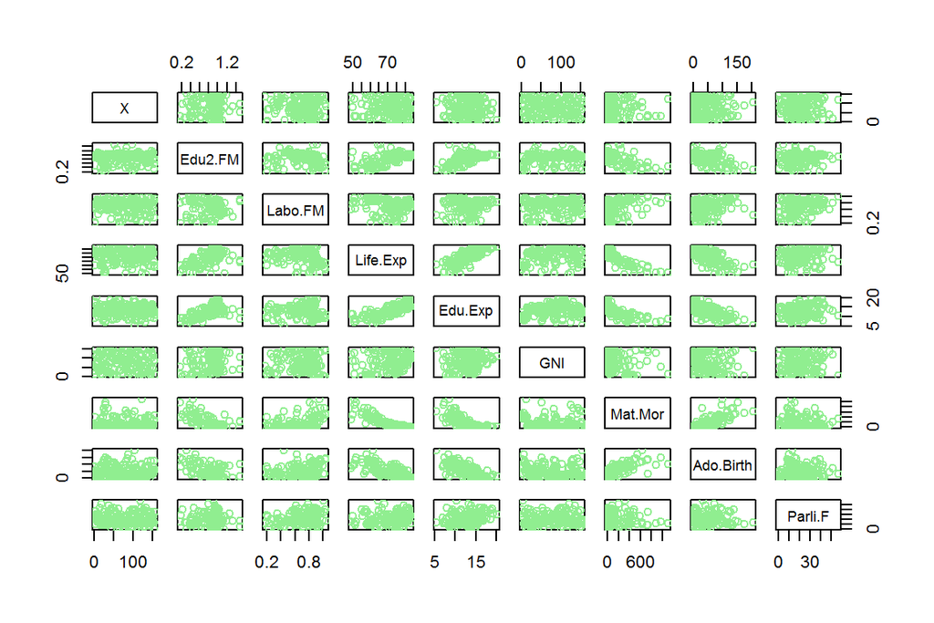

The summary of the variables shows the types of data they hold in. X is as described just a list of country names. Edu2FM is the ratio of secondary education and Labo.FM ratio of labour force participation wrangled in previous exercise. Life Exp shows the life expectancy in different nations where on average people live approximately 71 years. Expected years of education (Edu.exp) shows that in minimum people go to school for is 5 years.

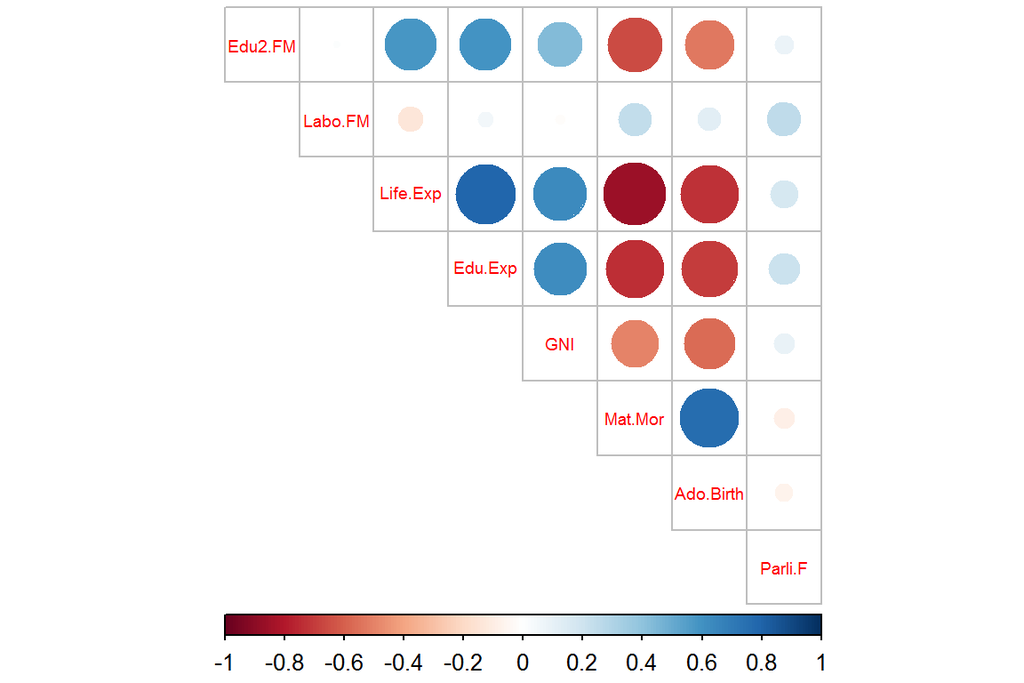

The correlation plot shows that there are strong correlations between the variables. In this graph clearly life expectancy and expected years of education correlate positively.

## Principal component analysis (PCA)

To perform PCA on the data frame, I have to first modify the data frame to make it numeric. First turn GNI into numeric form instead of factor and then remove column X from the data frame, since it contains string formed names. This has been already done for the correlation matrix in previous paragraph.

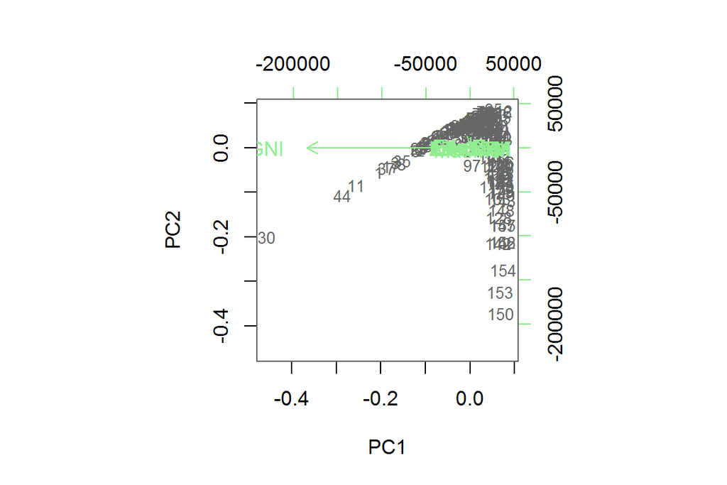

Above here is the biplot of data frame after PCA. The frame has not been standardized yet, which is why it has a strange shape. PCA maximizes the variance between variables and therefore without standardizing they tend to pack tightly or show only observations of one variable clearly. Some more information about why standardizing is needed are here: [Why do we need to normalize data before analysis?](http://stats.stackexchange.com/questions/69157/why-do-we-need-to-normalize-data-before-analysis)

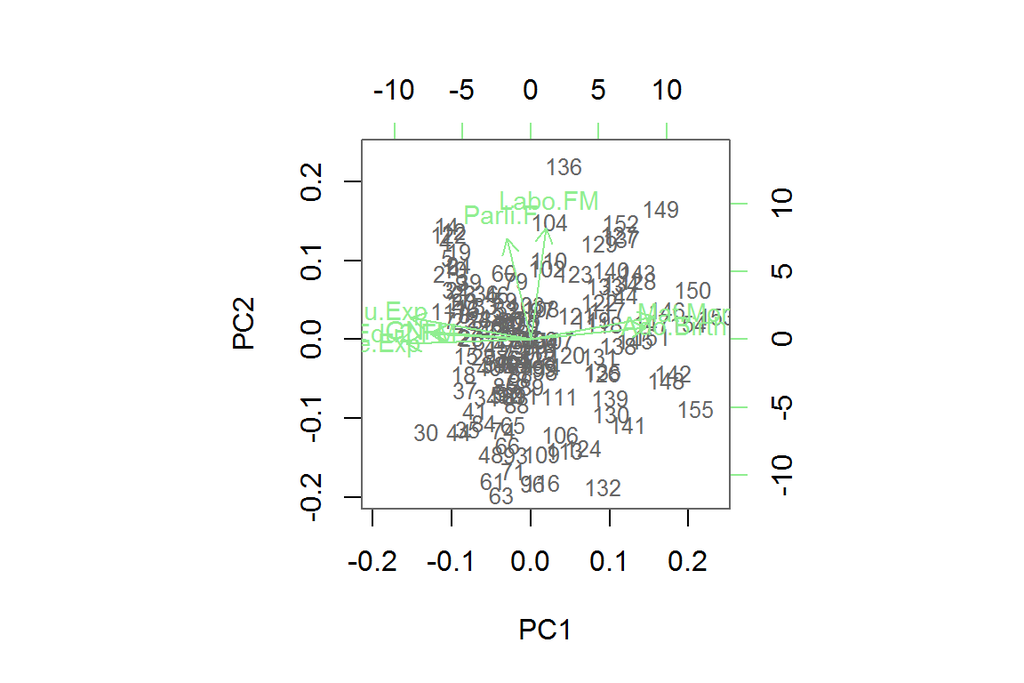

## Multiple correspondence analysis (MCA)

In this last part I loaded another dataset “tea” from FactoMineR- library to perform another dimension reduction technique, Multiple Correspondence analysis (MCA in short). This set contains answers from poll on things related to tea time. The structure and the dimensions of the data frame can be seen from below.

```
## 'data.frame':    300 obs. of  36 variables:
##  $ breakfast       : Factor w/ 2 levels "breakfast","Not.breakfast": 1 1 2 2 1 2 1 2 1 1 ...
##  $ tea.time        : Factor w/ 2 levels "Not.tea time",..: 1 1 2 1 1 1 2 2 2 1 ...
##  $ evening         : Factor w/ 2 levels "evening","Not.evening": 2 2 1 2 1 2 2 1 2 1 ...
##  $ lunch           : Factor w/ 2 levels "lunch","Not.lunch": 2 2 2 2 2 2 2 2 2 2 ...
##  $ dinner          : Factor w/ 2 levels "dinner","Not.dinner": 2 2 1 1 2 1 2 2 2 2 ...
##  $ always          : Factor w/ 2 levels "always","Not.always": 2 2 2 2 1 2 2 2 2 2 ...
##  $ home            : Factor w/ 2 levels "home","Not.home": 1 1 1 1 1 1 1 1 1 1 ...
##  $ work            : Factor w/ 2 levels "Not.work","work": 1 1 2 1 1 1 1 1 1 1 ...
##  $ tearoom         : Factor w/ 2 levels "Not.tearoom",..: 1 1 1 1 1 1 1 1 1 2 ...
##  $ friends         : Factor w/ 2 levels "friends","Not.friends": 2 2 1 2 2 2 1 2 2 2 ...
##  $ resto           : Factor w/ 2 levels "Not.resto","resto": 1 1 2 1 1 1 1 1 1 1 ...
##  $ pub             : Factor w/ 2 levels "Not.pub","pub": 1 1 1 1 1 1 1 1 1 1 ...
##  $ Tea             : Factor w/ 3 levels "black","Earl Grey",..: 1 1 2 2 2 2 2 1 2 1 ...
##  $ How             : Factor w/ 4 levels "alone","lemon",..: 1 3 1 1 1 1 1 3 3 1 ...
```

[output cut: 22 more lines]

```
## [1] 300  36
```

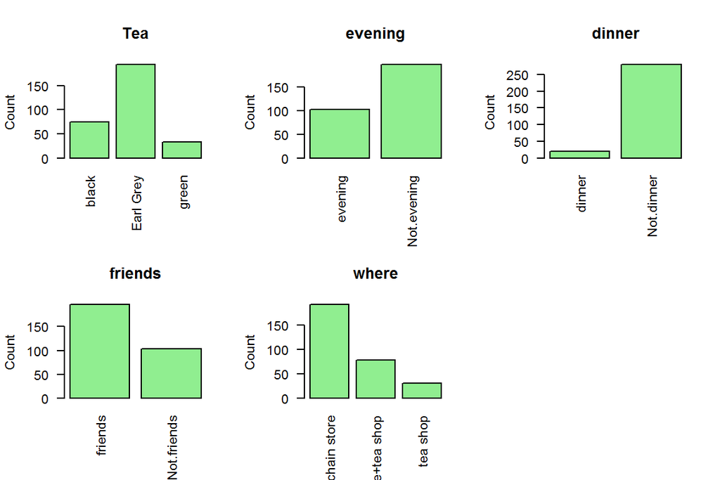

To perform MCA, I choose variables Tea, Evening, Dinner, Friends and Where.

```
##
## Call:
## MCA(X = tea_time, graph = FALSE)
##
##
## Eigenvalues
##                        Dim.1   Dim.2   Dim.3   Dim.4   Dim.5   Dim.6
## Variance               0.286   0.235   0.204   0.201   0.180   0.152
## % of var.             20.401  16.790  14.599  14.391  12.889  10.842
## Cumulative % of var.  20.401  37.191  51.790  66.181  79.070  89.913
##                        Dim.7
## Variance               0.141
## % of var.             10.087
## Cumulative % of var. 100.000
##
## Individuals (the 10 first)
##                Dim.1    ctr   cos2    Dim.2    ctr   cos2    Dim.3    ctr
## 1           |  0.492  0.283  0.199 | -0.834  0.986  0.570 |  0.459  0.344
## 2           |  0.492  0.283  0.199 | -0.834  0.986  0.570 |  0.459  0.344
## 3           |  0.062  0.004  0.001 |  0.912  1.179  0.247 | -0.556  0.505
## 4           |  0.881  0.905  0.231 |  0.405  0.232  0.049 | -0.527  0.453
## 5           | -0.019  0.000  0.000 | -0.388  0.214  0.151 | -0.420  0.287
## 6           |  0.881  0.905  0.231 |  0.405  0.232  0.049 | -0.527  0.453
## 7           | -0.160  0.030  0.057 | -0.064  0.006  0.009 | -0.388  0.246
## 8           |  0.154  0.028  0.016 | -0.743  0.782  0.368 |  0.429  0.300
## 9           | -0.046  0.002  0.002 | -0.111  0.017  0.010 |  0.119  0.023
## 10          | -0.213  0.053  0.023 | -0.374  0.198  0.072 |  0.938  1.434
##               cos2
## 1            0.173 |
## 2            0.173 |
## 3            0.092 |
## 4            0.083 |
## 5            0.176 |
## 6            0.083 |
## 7            0.336 |
## 8            0.123 |
## 9            0.012 |
## 10           0.450 |
##
## Categories (the 10 first)
```

[output cut: 15 more lines]

```
## evening       1.817 |  -0.045   0.068   0.001  -0.561 |
## Not.evening  -1.817 |   0.023   0.035   0.001   0.561 |
## dinner        9.457 |  -0.290   0.576   0.006  -1.376 |
## Not.dinner   -9.457 |   0.022   0.043   0.006   1.376 |
## friends       8.290 |   0.001   0.000   0.000   0.020 |
## Not.friends  -8.290 |  -0.002   0.000   0.000  -0.020 |
## chain store -10.269 |  -0.437  11.936   0.339 -10.065 |
##
## Categorical variables (eta2)
##               Dim.1 Dim.2 Dim.3
## Tea         | 0.351 0.172 0.672 |
## evening     | 0.185 0.011 0.001 |
## dinner      | 0.146 0.299 0.006 |
## friends     | 0.373 0.230 0.000 |
## where       | 0.373 0.463 0.343 |
```

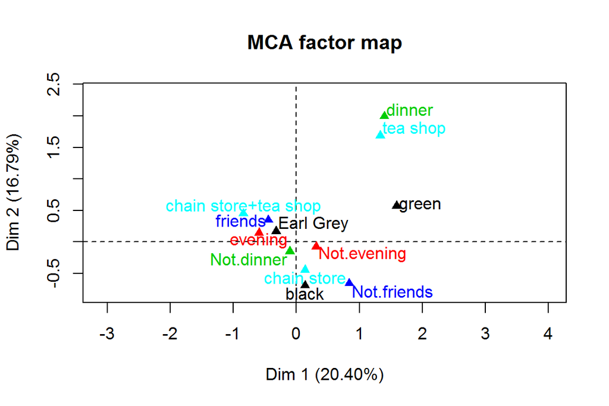

Clearly three variables stand from the crowd: dinner, tea shop and green tea. They do not come close to the dimensions and dinner and tea shop even correlate with each other. All the other variables gather around the origo of dimension values and do not oppse any particular dimension.